# DICE_DRINK 大话骰的游戏决策辅助

第一次玩大话骰这个游戏是在大学，和本科舍友玩的时候突然提了一嘴，似乎可以用统计的方法去进行游戏决策辅助，当时提了一嘴也没有多想，没想到在异国他乡的现在，和舍友在车上谈论的时候记忆又翻了回来，于是回来又研究了一下，用了一些很粗浅的统计知识去建了一个模，又编了一个小程序去进行辅助。仅供参考。

## 1.规则

大话骰规则如下：

- 每人的杯中有5个骰子，双方摇好后只可看到自己杯中所有骰子的点数。
- 一方先猜两个人杯中一共有N个T点，其中N取1到10间的一个整数，T 是1到6之间的整数。
- 这时对方有两种选择：
  - 不相信10个骰子中有N个T或大于N个T点，此时双方摊牌（掀杯），输赢自见分晓。
  - 猜10个骰子中有多余N个T，比如说N+1或N+2个T；也可以猜有N个更大的点数，比如说N个
  - T+1点或N个N+2点。原则是新猜的N和T都不能比对方上一次猜得小。
- 1点可以当任意点使用，比如五个骰子的点数是1，2，2，3，4，则可以说有三个2点，二个4点。
- 如果第一个猜骰子从1点开始猜起，即开始就猜共有N个1点，那么上一条规则作废，即在此轮游戏中，1点不再可以当任意点使用。

## 2.模型

我们需要输入的变量是

1. 参与游戏的人数n
2. 每个人的骰子数量p
3. 自己的骰子情况，使用向量表示每个数字的个数

$$(a,b,c,d,e,f)$$

表示有a个1，b个2，c个3，d个4，e个5，f个6。

$$a+b+c+d+e+f=p$$

容易知道，每个人的骰子满足多项分布(Multinomial distribution)

$$(a,b,c,d,e,f)\sim Multinomial(p,1/6)$$

可以得到联合概率分布为

$$P(A=a,B=b,C=c,D=d,E=e,F=f)=\frac{p!}{a!b!c!d!e!f!}(\frac{1}{6})^{p}$$

而$a,b,c,d,e,f$满足二项分布，可以得到

$$P(A=a)=\frac{p!}{a!(p-a)!}(\frac{1}{6})^a(\frac{5}{6})^{p-a}$$

在一次游戏中，使用$(a_1,a_2,a_3,...,a_n)$代表每个人的骰子中a的个数.

使用我们需要的是

$$P(\sum_{i=1}^{n-1}a_i=A)=\frac{((n-1)p)!}{A!((n-1)p-A)!}(\frac{1}{6})^A(\frac{5}{6})^{(n-1)p-A}$$

下面的函数是输入概率与每个人骰子的结果，返回这个结果的概率

```r
p=c(1/6,1/6,1/6,1/6,1/6,1/6)
multi <- function(p, x) {
  n <- sum(x)   ##试验次数

  f1 <- prod(p^x)
  f2 <- prod(factorial(x))
  return(factorial(n)*f1/f2)
}

x=c(1,1,1,1,1,1)
multi(p,x)
```

```
## [1] 0.0154321
```

下面是二项分布的代码

```r
x=c(0,1,2,3,4,5,6)
out=dbinom(x,6,1/6)
```

n为总人数，除自己之外的人数为n-1，自己的骰子的结果是已知的，所以除自己之外所有人每个数字的个数的概率为

```r
multi_n <- function(n_1,p,pro) {
  x=seq(0,n_1*p,by=1)

  out=pbinom(x,n_1*p,pro)

  return(out)
}
```

由于在游戏中，1可以代表任何数，所以实际上，单个骰子的结果，每个数字出现的概率是$1/3$。

## 3.实例

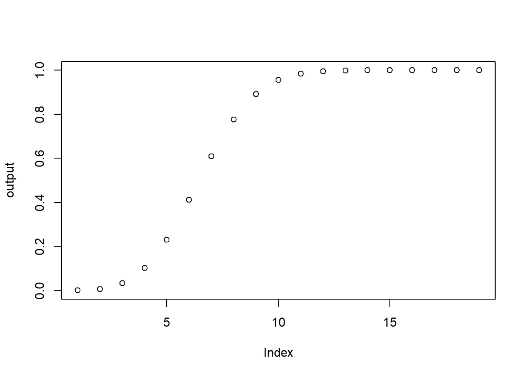

```r
n=4 #人数
n_1=n-1
p=6 #骰子的个数

output=multi_n(n_1,p,1/3)


plot(output)
```

```r
output
```

```
##  [1] 0.0006766395 0.0067663948 0.0326478551 0.1016650826 0.2310723840
##  [6] 0.4122426060 0.6085103465 0.7767398384 0.8923976140 0.9566519338
## [11] 0.9855663777 0.9960807210 0.9991474044 0.9998551006 0.9999814749
## [16] 0.9999983248 0.9999999045 0.9999999974 1.0000000000
```

```r
max(which(output<0.5))
```

```
## [1] 6
```

可以看到，对于每个数字，其余三个人中的骰子六个的概率最高。

## 4.策略

假设我们目前的骰子的结果为$x=(x_1,x_2,x_3,x_4,x_5,x_6)$，这是先验的，用$max(x)$表示个数最多的数字，$argmax(x)$表示最多的数量的数字。

假设对手，也就是上一家目前的骰子结果为$y=(y_1,y_2,y_3,y_4,y_5,y_6)$，用$max(y)$表示个数最多的数字，$argmax(y)$表示最多的数量的数字。上一家喊的骰子为a个b，记为$jd_y=(x,y)$。

Rmk: 对于我们来说，在对手理性的情况下，我们可以根据对手喊的骰子来判断对手的骰子分布，对手喊的骰子存在有效信息；但在对手是非理性的情况下，对手可能会存在夸大自己骰子的情况，来误导我们对于场上骰子数量偏向的判断。

所以，我们将对手分为两种情况来看，假设对手为理性，与假设对手不理性。

### 4.1假设对手为理性的

在对手为理性的情况下，我们要明确的一点是，对手喊的骰子与场上的骰子数量存在正相关性，也即

$$Corr(y,jd_y)>0$$

我们目前的骰子的结果为$x=(x_1,x_2,x_3,x_4,x_5,x_6)$，对手喊的为$jd_y=(num,int)$，我们将要喊的骰子为$jd_x=(X,Y)$，我们此时有两个选择

$$Y=int, \space or \space Y=argmax(x)$$

我们分别寻找在这两个选项下概率最大时的X。

当$Y=int$，我们拥有这个数字的个数是$y[int]$，在场上这个数字的总个数最大概率时的个数为

$$x[1]+x[int]+arg(binom([1:(n-1)*p],(n-1)*p,1/3))$$

由于理性对手中的int会相对多，所以这种情况下我们的决策为

$$\Big(x[1]+x[int]+arg(binom([1:(n-1)*p],(n-1)*p,1/3))+1,int \Big)$$
在这里，我们简单的加了一个1，因为我们可以根据先验信息，得到int的数量肯定会比无先验信息时的数量多，加一是最稳妥的做法。

当$Y=argmax(x)$时，我们的决策就是

$$\Big(x[1]+x[argmax(x)]+arg(binom([1:(n-1)*p],(n-1)*p,1/3)),argmax(x) \Big)$$

### 4.2假设对手为非理性的

在对手为非理性的情况下，对手有可能随机的耍诈，即喊的骰子结果与自己的骰子情况不符，也即我们不能通过对手喊的结果来判断$Corr(y,jd_y)$。

在这种情况下，我们选择最稳妥的办法，喊的策略与理性对手下$Y=argmax(x)$的策略一样

$$\Big(x[1]+x[argmax(x)]+arg(binom([1:(n-1)*p],(n-1)*p,1/3)),argmax(x) \Big)$$

或者

$$\Big(x[1]+x[int]+arg(binom([1:(n-1)*p],(n-1)*p,1/3)),int \Big)$$

## 代码

下面是对手理性的情况下的决策系统

```r
dice_judge= function(n_p,n_d,my_re,ene_judge,p){

  n_1=n_p-1
  output=multi_n(n_1,n_d,1/3)
  judge_int1=ene_judge[2]
  judge_int2=which.max(my_re)
  judge_num1=my_re[1]+my_re[judge_int1]+max(which(output<=p))+1
  judge_num2=my_re[1]+max(my_re)+max(which(output<=p))

  out_put=list(output1=c(judge_num1,judge_int1),output2=c(judge_num2,judge_int2))


  if (out_put[[1]][1]<ene_judge[1] | (out_put[[1]][1]==ene_judge[1] & out_put[[1]][2]<=ene_judge[2])){
    out_put$output1=0
  }

  if (out_put[[2]][1]<ene_judge[1] | (out_put[[2]][1]==ene_judge[1] & out_put[[2]][2]<=ene_judge[2])){
    out_put$output2=0
  }


  # if (out_put[[1]][1]==ene_judge[1] & out_put[[1]][2]<=ene_judge[2]){
  #   out_put$output1=NULL
  # }


  # if (out_put[[2]][1]==ene_judge[1] & out_put[[2]][2]<=ene_judge[2]){
  #   out_put$output1=NULL
  # }

  if (out_put$output1[1]==0){
    out_put$output1=NULL
  }

  if (out_put$output2[1]==0){
    out_put$output2=NULL
  }

  if (purrr::is_empty(out_put)){
    out_put="over"
  }

  return(out_put)
}
```

上面的代码就是整个决策系统，这里的n_p代表有多少人，n_d代表每个人有几个骰子，my_re代表我的骰子结果，ene_judge代表上一家的骰子的声明，p代表我的风险期望，一般都是0.5，也就是代表我希望的获胜概率在$1-0.5=50%$以上，但由于大话骰属于游戏，存在非理性的情况，大家的风险预期会增加，所以可以适当提高p来增加风险。

下面示范

```r
a=dice_judge(n_p=4,n_d=6,my_re=c(1,1,3,1,0,0),ene_judge=c(10,2),p=0.5)
a
```

```
## $output2
## [1] 10  3
```

上面的例子代表，如果有四个人玩游戏，每个人6个骰子，一局中我的骰子为$(1,1,3,1,0,0)$，上一家喊的是10个2，风险期望是0.5，那我应该喊10个3。

另一个例子

```r
a=dice_judge(n_p=4,n_d=6,my_re=c(1,2,2,1,0,0),ene_judge=c(10,2),p=0.5)
a
```

```
## [1] "over"
```

如果有四个人玩游戏，每个人6个骰子，一局中我的骰子为$(1,2,2,1,0,0)$，上一家喊的是10个2，风险期望是0.5，那我应该质疑上一家。

## 结论

对手在非理性的情况下的决策模型约等于理性情况，这边就不做展示了。

本决策系统没有考虑对手喊1的情况，也就是没有考虑最后一条规则。

整体模型比较粗糙，有几个改进方向。一是可以通过学习对手的以往的游戏来判断对手是非理性还是理性，通过学习游戏习惯来改变自己的策略；二是可以通过以往的游戏判断大家的风险期望，来动态调整p。